# Simulations In-Class Project

Due October 13, 2017 at 11:59pm

[output not shown]

# Project Goals:

With this project we will simulate a famous probability problem. This will not require knowledge of probability or statistics but only the logic to follow the steps in order to simulate this problem. This is one way to solve problems by using the computer.

Since you all have completed problem 1, yaou first step will be to work through each of your groupmates code for problem #1 and comment on what is happening. Then as a team move forward in on direction as you move on to the rest of the problems 2-5

1. **Gambler’s Ruin**: Suppose you have a bankroll of $1000 and make bets of $100 on a fair game. By simulating the outcome directly for at most 5000 iterations of the game (or hands), estimate:

(Note: you *must* stop playing if your player has gone bust. How will you handle this in the `for` loop?)

```r
bankroll<-1000
bet<- 100
trials<-5000
perc<-0.5

gambler<- function(B, b, N, p) {
  # B: bankroll
  #b: bet
  #N: number of trials
  #p: probability of winning

  game<-rep(NA,N) #this creates a vector of NAs that will store all the results
  game[1]<-B #first hand of game gets assigned initial bankroll
  for (i in 2:N) { #repeat until we reach trial limit
    hand <- game[i-1] + 2*b*rbinom(1, 1, prob = p) - b #each hand we can either increase the previous hand's bankroll by bet amount or lose the bet amount
    game[i]<-hand #store the hand's result
    if (game[i]==0) { #whenever we reache a game where bankroll is =0
        return(game[1:i]) #return the vector of results
        break
    }
  }
  return(game) #if we reache the trial limit, return whole vector
}

simul.result<-replicate(trials, gambler(bankroll, bet, trials, perc))
```

1. the probability that you have “busted” (lost all your money) by the time you have placed your one hundredth bet.

```r
p.bust.100<- sum(sapply(simul.result, function(x) length(x)<100))/trials
p.bust.100
```

```
## [1] 0.308
```

2. the probability that you have busted by the time you have placed your five hundredth bet by simulating the outcome directly.

```r
p.bust.500<- sum(sapply(simul.result, function(x) length(x)<500))/trials
p.bust.500
```

```
## [1] 0.648
```

3. the mean time you go bust, given that you go bust within the first 5000 hands.

```r
mean.bust<-sapply(simul.result, function(x) length(x))
mean.bust<-mean(mean.bust[mean.bust<5000])
mean.bust
```

```
## [1] 538
```

4. the mean and variance of your bankroll after 100 hands (including busts).

```r
hand.100<-sapply(simul.result, "[", 100)
hand.100[is.na(hand.100)]<-0
mean.100<-mean(hand.100, na.rm = TRUE)
var.100<-var(hand.100, na.rm = TRUE)
mean.100
```

```
## [1] 1006
```

```r
var.100
```

```
## [1] 830500
```

5. the mean and variance of your bankroll after 500 hands (including busts).

```r
hand.500<-sapply(simul.result, "[", 500)
hand.500[is.na(hand.500)]<-0
mean.500<-mean(hand.500, na.rm = TRUE)
var.500<-var(hand.500, na.rm = TRUE)
mean.500
```

```
## [1] 1001
```

```r
var.500
```

```
## [1] 2656370
```

2. Repeat the previous problem with betting on black in American roulette, where the probability of winning on any spin is 18/38 for an even payout.

```r
perc.rou<-18/38
simul.roulette<-replicate(trials, gambler(bankroll, bet, trials, perc.rou))
```

1. the probability that you have “busted” (lost all your money) by the time you have placed your one hundredth bet.

```r
p.bust.100.roulette<- sum(sapply(simul.roulette, function(x) length(x)<100))/trials
p.bust.100.roulette
```

```
## [1] 0.499
```

2. the probability that you have busted by the time you have placed your five hundredth bet by simulating the outcome directly.

```r
p.bust.500.roulette<- sum(sapply(simul.roulette, function(x) length(x)<500))/trials
p.bust.500.roulette
```

```
## [1] 0.921
```

3. the mean time you go bust, given that you go bust within the first 5000 hands.

```r
mean.bust.roulette<-sapply(simul.roulette, function(x) length(x))
mean.bust.roulette<-mean(mean.bust.roulette[mean.bust.roulette<5000])
mean.bust.roulette
```

```
## [1] 186
```

4. the mean and variance of your bankroll after 100 hands (including busts).

```r
hand.100.roulette<-sapply(simul.roulette, "[", 100)
hand.100.roulette[is.na(hand.100.roulette)]<-0

mean.100.roulette<-mean(hand.100.roulette, na.rm = TRUE)
var.100.roulette<-var(hand.100.roulette, na.rm = TRUE)
mean.100.roulette
```

```
## [1] 596
```

```r
var.100.roulette
```

```
## [1] 567833
```

4. the mean and variance of your bankroll after 500 hands (including busts).

```r
hand.500.roulette<-sapply(simul.roulette, "[", 500)
hand.500.roulette[is.na(hand.500.roulette)]<-0

mean.500.roulette<-mean(hand.500.roulette, na.rm = TRUE)
var.500.roulette<-var(hand.500.roulette, na.rm = TRUE)
mean.500.roulette
```

```
## [1] 156
```

```r
var.500.roulette
```

```
## [1] 379959
```

3. **Markov Chains**. Suppose you have a game where the probability of winning on your first hand is 48%; each time you win, that probability goes up by one percentage point for the next game (to a maximum of 100%, where it must stay), and each time you lose, it goes back down to 48%. Assume you cannot go bust and that the size of your wager is a constant $100.

```r
markov.trials<-100000 #set number of trials
markov.p<-0.48 #set initial probability

gambler.markov<- function(b, N, p) {
  #b: bet
  #N: number of trials
  #p: probability of winning

  game<-rep(NA,N) #this creates a vector of NAs
  z<-p #since probability might change depending on the outcome oh the hand, store probability in a new vector

  for (i in 1:N) { #the game works similarly to the previous ones
    win<-rbinom(1, 1, prob = z)
    if (i ==1) { #for the first hand we don't refer to the previous hand's outcome
      hand<-2*b*win - b
    } else {
        hand <- game[i-1] + 2*b*win - b #in the following hands of the game, you can either increase or decrease your bankroll bis the size of the bet.
    }
    game[i]<-hand
    if (win==1) { #the probablity of the next hand in the game will change depending if you win or not
      z<-z + 0.01
      if (z>1) {
        z<-1
      }
    } else {
      z<- p
    }
  }
  return(game)
}

simul.markov<-replicate(100, gambler.markov(bet, markov.trials, markov.p))
```

1. Is this a fair game? Simulate one hundred thousand sequential hands to determine the size of your return. Then repeat this simulation 99 more times to get a range of values to calculate the expectation.

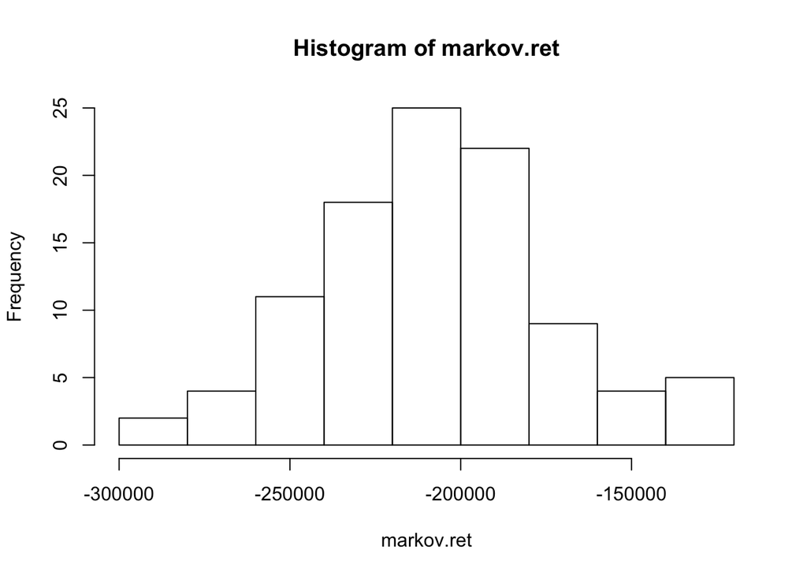

```r
markov.ret<-simul.markov[dim(simul.markov)[1],] # markov returns
hist(markov.ret)
```

```r
range(markov.ret)
```

```
## [1] -285000 -120400
```

```r
mean(markov.ret)
```

```
## [1] -208500
```

2. Repeat this process but change the starting probability to a new value within 2% either way. Get the expected return after 100 repetitions. Keep exploring until you have a return value that is as fair as you can make it. Can you do this automatically?

```r
rng<- seq(from = 0.46, to = 0.50, by = 0.01)
markov.rng<-matrix(data = NA, nrow = length(rng), ncol = 2)
for (t in 1:length(rng)) {
  try.prob<-rng[t]
  markov.rng[t,1]<-rng[t]
  simul.markov<-replicate(100, gambler.markov(bet, markov.trials, try.prob))
  markov.ret<-simul.markov[dim(simul.markov)[1],] # markov returns
  markov.rng[t,2]<-mean(markov.ret)
}
```

[output not shown]

The steps of this process are:

1. Draw a sample, with replacement, from your data which is the same length of your data.
2. Calculate the statistic of interest on this boostrap sample (ie mean, variance, regression,…)
3. Peform steps 1:2 at least 1000 times over until you have a vector of your statistics.
4. The lower bound of a 95% CI will be the 0.025 percentile
5. The upper bound of a 95% CI will be the 0.975 percentile

Make a function called `boot_ci` which calculates the 95% confidence interval in this manner.

```r
boot_ci = function(x, iter) {
  #x: data to sample from
  #iter: number of times you will draw a sample
  boot_statistic = numeric()
  for (i in 1:iter){
    boot_sample = sample(x, size = length(x), replace=TRUE)
    boot_statistic[i] <- mean(boot_sample)
  }
  boot_se <- sd(boot_statistic)
  return(boot_se)
}

# Assumptions
  # size = 10000
  # mean = 0
  # sd = 1
# TEST
# mydata <- rnorm(size, mean, sd)
# mydata_mean = mean(mydata)
# mydata_se=boot_ci(mydata, 10000)
# mydata_mean_ci <- mydata_mean + qt( c(0.025, 0.975), length(mydata) - 1) * mydata_se
```

3b

```r
markov.se = boot_ci(markov.ret, 10000)
markov.var =  markov.se^2
markov.var
```

```
## [1] 4064468100
```